# R Notebook

```r
setwd("~/Documentos/Rstudio/TFM") #xq cada documento me cambia la ruta
source("IPI_O.R")
```

```
Classes ‘tbl_df’, ‘tbl’ and 'data.frame':   524 obs. of  8 variables:
 $ X__1                         : chr  "2018M08" "2018M07" "2018M06" "2018M05" ...
 $ Índice general               : num  100.2 105.9 100.9 102.4 96.9 ...
 $ Bienes de consumo            : num  110 106 102 106 100 ...
 $ Bienes de consumo duradero   : num  100 94.6 93.9 92.8 86.7 ...
 $ Bienes de consumo no duradero: num  110 106 102 106 100 ...
 $ Bienes de equipo             : num  93.4 156.2 144.2 136.3 110.6 ...
 $ Bienes intermedios           : num  87.6 95.7 97.2 102.1 95.2 ...
 $ Energía                      : num  99 95.9 90.4 92.3 92.1 ...
Classes ‘tbl_df’, ‘tbl’ and 'data.frame':   499 obs. of  8 variables:
 $ X__1                         : chr  "2018M08" "2018M07" "2018M06" "2018M05" ...
 $ Índice general               : num  3.4 3.1 4.8 7.3 6.5 -3.2 0.2 -2.8 1.5 7.8 ...
 $ Bienes de consumo            : num  12.2 2.5 -1.2 12.2 10.9 -11.7 -9.4 -7.4 3.1 9.1 ...
 $ Bienes de consumo duradero   : num  12.3 2.3 13.1 -0.3 18.1 1.3 -13.4 12.4 3.9 -32.1 ...
 $ Bienes de consumo no duradero: num  12.2 2.5 -1.5 12.6 10.8 -12.1 -9.3 -7.8 3.1 10.6 ...
 $ Bienes de equipo             : num  34.9 27.1 67 51 26.6 11.3 10.8 -1.2 2.9 11.4 ...
 $ Bienes intermedios           : num  -2.8 -1.1 5.2 1.4 9.3 -10.5 1.8 10.7 3.7 12.1 ...
 $ Energía                      : num  -5.3 -2.9 -5.3 -4.2 -1.2 0.7 3 -3 -0.2 5 ...
```

[output not shown]

# TEORÍA PREVIA

## Transferencia de información

Una aproximación interesante al estudio del Índice de producción industrial es determinar que otros datos recabados por el Instituto Nacional de Estadística pueden darnos información acerca de dicho índice.

Para ello existe toda una rama de la teoría matemática y las ciencias de la computación llamada teoría de la información. Esta teoría matemática de la comunicación fué creada por Cloude E. Shannon y Warren Weaver a finalles de la segunda guerra mundial como resultado de buscar la manera más eficiente de transmitir información.

Una primera aproximación para estimar la cantidad de información que cierta variable $I$ nos aporta sobre $J$ es la información mutua:

$M_{IJ}= \sum{p(i,j)log \frac{p(i,j)}{p(i)p(j)}}$.

\$p(i,j)$ es la probabilidad conjunta

Esta es una medida simétrica y por tanto carece de un sentido de direccionalidad. (Se le puede añadir un sentido de direccionalidad añadiedo la historia de uno de los parámetros)

Siendo $I$ y $J$ dos variables aleatorias con una distribución de probabilidad $p(i)$ y $p(j)$ y una distribuación de probailidad conjunta $p(i,j)$ cuya estructura dinámica corresponde a la de una proceso de tipo Markov estacionario de orden $k$ La propiedad de Markov implica lo siguiente: $p(i_{t+1}|i_t,...,i_{t−k+1})=p(i_{t+1}|i_t,...,i_{t−k})$. La probabilidad de observar el suceso $I$ en el estado $i$ en el momento $t+1$ condicionado a a las $k$ observaciones anteriores es igual a las condicionadas a las $k-1$ observaciones anteriores. Usando a partir de ahora la notación $i^{(k)} = (i_n,...,i_{n--k+1})$ Usando la fórmula análoga a la información mutua, el número de bits que se precisan para codificar un estado del sistema conociendo k estados anteriores es dado por la siguiente fórmula.

$h_I(k)=−∑ip(i_{t+1},i^{(k)}_t)⋅log(p(i_{t+1}|i^{(k)}_t)),$

where $i^{(k)}_t=(i_t,...,i_{t−k+1}). h_J(l)$ can be derived analogously for process J.

La entropía de Kulback es la cantidad de bits de más que se necesitan para codificar $I$ si en vez de la distribución de probabilidades $p(i)$ se usa la $q(i)$

$T_{j->I} = \sum p(i_{n+1})log(\frac{p(i_{n+1}|i_n,...,i_{n--k+1}, j_n)}{p(i_{n+1}|i_n,...,i_{n--k+1})})$

$T_{j->I}$ mide el flujo de información de $J$ a $I$

### Transferencia Efectiva de Infomración

### Eliminación del Sesgo por efecto de muestras demasiado pequeñas

Para eliminar el sesgo debido a un tamaño demasiado pequeño de muestra se calculan sucesivas transferencias de información para una versión barajada de la serie temporal $T_{j_{shuffled}->I}$, esta transferencia de información converge hacia el cero a medida que el tamaño de la muestra aumenta. Para calcular la transferencia de entropía efectiva se calcula la media de todos los cálculos de $T_{j_{shuffled}->I}$ y se resta a la transferencia de entropía para así obtener una medida corregida.

### Cálculo de p-value

Para poder aproximar el significado estadístico de la transferencia de entropía se usa el método de “Markov block bootstrap”. Este método permite hacer remuestreo aleatorio con reemplazamiento respetando las dependencias dentro de la serie temporal. De esta manera, se calcula una distribución de transferencias de entropía bajo la hipótesis nula de la 0 transferencia de información. Estas series temporales creadas retienen las dependencias entre la serie temporal $J$ pero elimina la dependencia estadística entre $J$ e $I$. Se obtiene la distribución de transferencia de entropía siendo la hipótesis nula el flujo nulo de entropía. El p-value asociado hasta hipótesis nula se ibtiene mediante $1-\^{q}_{TE}$ donde $\^{q}$ es el cuartil de la transferencia de entropíade la serie temporal original

# ESTUDIO

Para se crea una sola tabla con todos las tablas con las quese va a estudiar la transferencia de entropía existente con el Índice de producción industrial.

```r
conjunto2<-cbind(cbind.xts(EN,`colnames<-`(consumo_gas,paste("consumo",colnames(consumo_gas)))),precio_gas)
conjunto2<-cbind.xts(conjunto2,ocupacion_aprox)
conjunto2<-cbind.xts(conjunto2,turismo)
conjunto2<-cbind.xts(conjunto2,sup_construida)
colnames(conjunto2)
```

```
 [1] "Energía.eléctrica.disponible"          "Producción.bruta.de.energía.eléctrica"
 [3] "Consumo.de.energía.eléctrica"          "consumo.FUELÓLEO"
 [5] "consumo.GASÓLEO"                       "consumo.GASOLINA"
 [7] "Precio.del.petróleo..barril.Brent."    "población.ocupada"
 [9] "Alojamientos.turísticos.abiertos"      "Superficie.a.construir.m2."
```

```r
head(conjunto2)
```

```
           Energía.eléctrica.disponible Producción.bruta.de.energía.eléctrica Consumo.de.energía.eléctrica
1986-01-01                           NA                                    NA                           NA
1986-02-01                           NA                                    NA                           NA
1986-03-01                           NA                                    NA                           NA
1986-04-01                           NA                                    NA                           NA
1986-05-01                           NA                                    NA                           NA
1986-06-01                           NA                                    NA                           NA
           consumo.FUELÓLEO consumo.GASÓLEO consumo.GASOLINA Precio.del.petróleo..barril.Brent.
1986-01-01               NA              NA               NA                               2235
1986-02-01               NA              NA               NA                               1720
1986-03-01               NA              NA               NA                               1398
1986-04-01               NA              NA               NA                               1235
1986-05-01               NA              NA               NA                               1406
1986-06-01               NA              NA               NA                               1197
           población.ocupada Alojamientos.turísticos.abiertos Superficie.a.construir.m2.
1986-01-01                NA                               NA                         NA
1986-02-01                NA                               NA                         NA
1986-03-01                NA                               NA                         NA
1986-04-01                NA                               NA                         NA
1986-05-01                NA                               NA                         NA
1986-06-01                NA                               NA                         NA
```

## p-VALUES

Para comenzar se comparará el p-value de todas los tablas con el IPI general para, en un primer momento, descartar las que den un p-value demasiado alto y hacer un estudio más detallado de las que resulten más interesantes

En la gráfica número 1 se representan los distintos valores de p-value

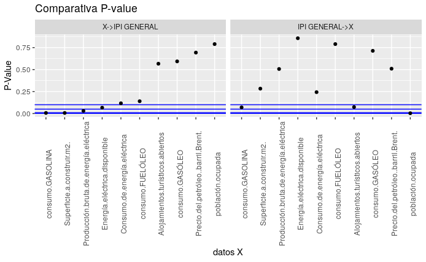

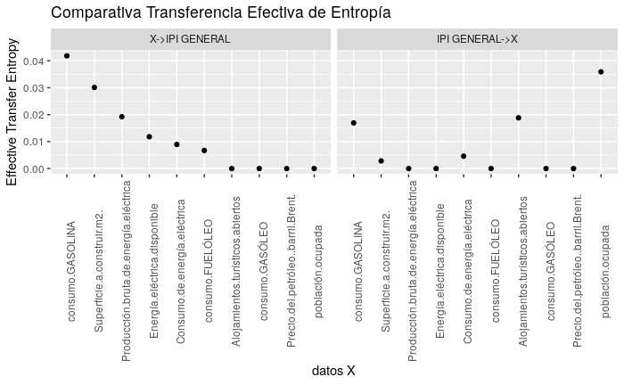

```r
compara(conjunto2,IPI$`Índice general`)
```

Ipi aporta información: sobre el consumo de gasolina, la población ocupada

datos que aportan información sobre el IPI * consumo de gasolina * licitaciones de obra * producción EL * EL disponible

estos 4 datos formarán el conjunto a utilizar para el forecasting multivariado

```r
conjuntofc<-cbind.xts(EN$`Energía eléctrica disponible`, EN$`Producción bruta de energía eléctrica`)
conjuntofc<-cbind.xts(conjuntofc, consumo_gas$GASOLINA)
conjuntofc<-cbind.xts(conjuntofc, sup_construida)
conjuntofc<- cbind.xts(conjuntofc, IPI$`Índice general`)
conjuntofc<-conjuntofc[paste(start(IPI$`Índice general`), end(IPI$`Índice general`), sep = "/")]
write.csv(as.data.frame(conjuntofc), "conjuntofc.csv", row.names = TRUE)
```

```r
conjuntofake<-cbind.xts(EN$`Consumo de energía eléctrica`, precio_gas)
conjuntofake<-cbind.xts(conjuntofake, consumo_gas$FUELÓLEO)
conjuntofake<-cbind.xts(conjuntofake, sup_construida)
conjuntofake<- cbind.xts(conjuntofake, IPI$`Índice general`)
conjuntofake<-conjuntofake[paste(start(IPI$`Índice general`), end(IPI$`Índice general`), sep = "/")]
write.csv(as.data.frame(conjuntofake), "conjuntofcfake.csv", row.names = TRUE)
```

Ipi aporta información: sobre el consumo de gasolina, la población ocupada